# Cloud Services Product Design Decision Making

Marketing Analytics

Author: Vishal Gopalkrishna

## To the Reader

In this project, I have built a model that predicts the product features preffered by customers on a product created by a cloud services platform. This enable the manufacturing team to understand the needs of it’s consumer base and create products that address these needs.

*It also allows the senior management and the marketing team to create profit making and marketing strategies to maximize sales. Finally, enables the business to make advantageous pricing decisions to secure a customer base while ensuring maximum profits.*

## Context

The data set is the result of a Choice-Based conjoint study in a Cloud Services Platform market. The objective is to make design decisions such as core feature sets, pricing and tiers of service to increase profits and attract new customers.

To achieve this, 200 respondents were asked to evaluate 15 choice sets, each containing 3 alternatives. A respondent had to choose one alternative from a choice set. Each Alternative is a combination of 4 attributes.

*An example of a choice made by one of the 200 respondents, say respondent 34 could be:*

Choice Set 1 has 3 Alternatives: Alternative 1, Alternative 2 and Alternative 3. Each Alternative has 4 features or “attributes”

- Alternative 1 : 30GB, yes to customer support, email, £12 per month.
- Alternative 2 : 2000GB, no to customer support, email and video, £18 per month.
- Alternative 3 : 5000GB, no to customer support, email, £12 per month.

The respondent 34 could choose Alt 3 from this choice set 1 and choose a particular Alternative in each of the other 14 choice sets. The same is repeated for all 200 respondents.

*Our Aim is to build a model that predicts which Alternative will be choosen in each choice set.*

## Descriptive Statistics

```r
data <- read.csv("cloud.csv", stringsAsFactors = T)

data <- as_tibble(data)

summary(data)
```

```
 respondent_id     choiseset_id alternative_id   choice_id      cloud_storage
 Min.   :  1.00   Min.   : 1    Min.   :1      Min.   :   1.0   2000gb:3004
 1st Qu.: 50.75   1st Qu.: 4    1st Qu.:1      1st Qu.: 750.8   30gb  :3003
 Median :100.50   Median : 8    Median :2      Median :1500.5   5000gb:2993
 Mean   :100.50   Mean   : 8    Mean   :2      Mean   :1500.5
 3rd Qu.:150.25   3rd Qu.:12    3rd Qu.:3      3rd Qu.:2250.2
 Max.   :200.00   Max.   :15    Max.   :3      Max.   :3000.0
 customer_support                    cloud_services price          choice
 no :4525         email                     :2999   p12:2977   Min.   :0.0000
 yes:4475         email, video              :3001   p18:3023   1st Qu.:0.0000
                  email, video, productivity:3000   p6 :3000   Median :0.0000
                                                               Mean   :0.3333
                                                               3rd Qu.:1.0000
                                                               Max.   :1.0000
```

The “respondent_id” is a unique identifier for each respondent from 1 to 200. “choiseset_id” identifies the choice set from 1 to 15. “alternative_id” identifies 3 unique alternatives available in every choice set. Finally, “choice_id” is an identifier of the choice sets in the entire study.

We have 4 attributes variables describing cloud storage options, customer support availability, cloud services options and monthly prices. Finally, the choice variable describes the choice made in each choice set by every respondent.

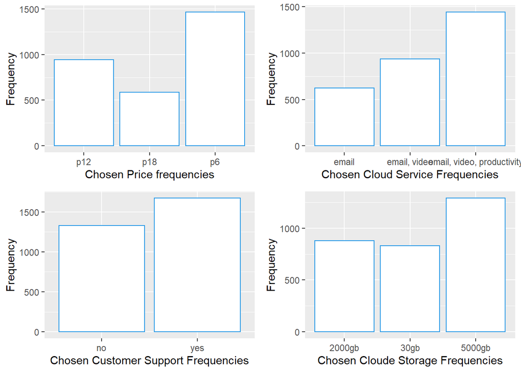

```r
z1<-data %>%
  filter(choice==1) %>%
  select(price) %>%
  ggplot(aes(price)) +
  geom_bar(bins = 15,
                 color = 4,
                 fill = "white") +
  labs(x = "Chosen Price frequencies", y = "Frequency")

z2<-data %>%
  filter(choice==1) %>%
  select(cloud_services) %>%
  ggplot(aes(cloud_services)) +
  geom_bar(bins = 15,
           color = 4,
           fill = "white") +
  labs(x = "Chosen Cloud Service Frequencies", y = "Frequency")

z3<-data %>%
  filter(choice==1) %>%
  select(customer_support) %>%
  ggplot(aes(customer_support)) +
  geom_bar(bins = 15,
           color = 4,
           fill = "white") +
  labs(x = "Chosen Customer Support Frequencies", y = "Frequency")

z4<-data %>%
  filter(choice==1) %>%
  select(cloud_storage) %>%
  ggplot(aes(cloud_storage)) +
  geom_bar(bins = 15,
           color = 4,
           fill = "white") +
  labs(x = "Chosen Cloude Storage Frequencies", y = "Frequency")

grid.arrange(z1,z2,z3,z4, nrow=2,ncol=2)
```

The above figure shows the distribution of the frequency in which the attributes are chosen in each of the choice set. Most respondents (close to 50%) chose the £6 per month option indicating that lower monthly prices are more preferable.

## Data Pre-Processing

We start with introducing levels in the “cloud_storage” variable, as the contents of this variable, namely “30GB”, “2000GB” and “5000GB” have an order. That is, 2000GB is bigger or more than 30GB.

Similarly, we re-level “price”. The other 2 attribute variable don’t need relevelling because they don’t have an order.

```r
data$cloud_storage <- relevel(data$cloud_storage, ref = "30gb")
data$price <- relevel(data$price, ref = "p6")
```

Next, we notice that “customer_support” is a binary variable with values “yes” and “no” indicating the presence and absence of customer support. “cloud_services” is a variable with levels that don’t have any order or a hierarchy. Choosing “Email” is not greater than or higher than choosing “Email + Video”, its just a personal choice.

We remove the character “p” from the price variable to make it a numeric variable.

```r
data$price_n <- data$price

data <- data %>%
  mutate(price_n = gsub("p", "", price_n), # remove character 'p' from
         price_n = as.numeric(price_n)) # turn the variable into numeric class
```

## Data Exploration

```r
mean(data$price_n)
```

```
[1] 12.01533
```

Users on an average pay £12.0153 per month.

```r
data %>%
  filter(choice==1) %>%
  select(cloud_storage) %>%
  summary()
```

```
 cloud_storage
 30gb  : 830
 2000gb: 881
 5000gb:1289
```

```r
data %>%
  filter(choice==1) %>%
  select(cloud_services) %>%
  group_by(cloud_services) %>%
  summarise(count=n()) %>%
  mutate(Percentage=round(x=count/sum(count)*100, digits = 1))
```

```
# A tibble: 3 x 3
  cloud_services             count Percentage
  <fct>                      <int>      <dbl>
1 email                        624       20.8
2 email, video                 935       31.2
3 email, video, productivity  1441       48
```

Notice that, 30GB was chosen 830 times and 20.8% of the respondents chose email only as cloud service.

## Data Modelling

We now create a the multinomial logit models with individual and/or alternative specific variables. This enables us to understand what features would drive more sales and concequently more profit.

```r
library(mlogit)
set.seed(123)
model1 <- mlogit(choice~ 0+
                   cloud_storage+
                   customer_support+
                   cloud_services+
                   price,
                 data = m_data)
summary(model1)
```

```
Call:
mlogit(formula = choice ~ 0 + cloud_storage + customer_support +
    cloud_services + price, data = m_data, method = "nr")

Frequencies of alternatives:choice
    1     2     3
0.329 0.338 0.333

nr method
5 iterations, 0h:0m:0s
g'(-H)^-1g = 0.000101
successive function values within tolerance limits

Coefficients :
                                          Estimate Std. Error  z-value
cloud_storage2000gb                       0.165323   0.063785   2.5919
cloud_storage5000gb                       0.894883   0.063235  14.1517
customer_supportyes                       0.493309   0.051708   9.5403
cloud_servicesemail, video                0.632000   0.065736   9.6142
cloud_servicesemail, video, productivity  1.490839   0.067121  22.2112
pricep12                                 -0.836795   0.059963 -13.9551
pricep18                                 -1.601502   0.067640 -23.6770
                                                      Pr(>|z|)
cloud_storage2000gb                                   0.009545 **
cloud_storage5000gb                      < 0.00000000000000022 ***
customer_supportyes                      < 0.00000000000000022 ***
cloud_servicesemail, video               < 0.00000000000000022 ***
cloud_servicesemail, video, productivity < 0.00000000000000022 ***
pricep12                                 < 0.00000000000000022 ***
pricep18                                 < 0.00000000000000022 ***
---
Signif. codes:  0 '***' 0.001 '**' 0.01 '*' 0.05 '.' 0.1 ' ' 1

Log-Likelihood: -2567.8
```

The coefficient estimate of cloud_storage5000gb is 0.8948 and is statistically significant at a 99% confidence. This gives us the highest utility among all other level in this attribute. Which means the storage option of 5000GB is most proffered.

The coefficient of pricep12 is negative at a value of -0.8367 and it is significant at 99%. Both coefficients of the price levels are negative indicating that the reference level, pricep6 has the highest utility.

**Let us build a another model creating a new “price” variable called “price_n” which is numerical instead of the categorical variable “price”**

```r
set.seed(123)
model2 <- mlogit(choice~ 0+
                   cloud_storage+
                   customer_support+
                   cloud_services+
                   price_n,
                 data = m_data)
summary(model2)
```

```
Call:
mlogit(formula = choice ~ 0 + cloud_storage + customer_support +
    cloud_services + price_n, data = m_data, method = "nr")

Frequencies of alternatives:choice
    1     2     3
0.329 0.338 0.333

nr method
5 iterations, 0h:0m:0s
g'(-H)^-1g = 9.84E-05
successive function values within tolerance limits

Coefficients :
                                          Estimate Std. Error  z-value
cloud_storage2000gb                       0.165169   0.063776   2.5898
cloud_storage5000gb                       0.894500   0.063226  14.1477
customer_supportyes                       0.493446   0.051704   9.5437
cloud_servicesemail, video                0.632170   0.065713   9.6201
cloud_servicesemail, video, productivity  1.490244   0.067103  22.2082
price_n                                  -0.133936   0.005603 -23.9041
                                                      Pr(>|z|)
cloud_storage2000gb                                   0.009602 **
cloud_storage5000gb                      < 0.00000000000000022 ***
customer_supportyes                      < 0.00000000000000022 ***
cloud_servicesemail, video               < 0.00000000000000022 ***
cloud_servicesemail, video, productivity < 0.00000000000000022 ***
price_n                                  < 0.00000000000000022 ***
---
Signif. codes:  0 '***' 0.001 '**' 0.01 '*' 0.05 '.' 0.1 ' ' 1

Log-Likelihood: -2568
```

As price_n takes higher values, the utility decreases implying that the respondents prefer to pay less.

**Let us next compare Models 1 and 2 with a likelihood-ratio test**

```r
# likelihood-ratio test
lrtest(model2, model1)
```

```
Likelihood ratio test

Model 1: choice ~ 0 + cloud_storage + customer_support + cloud_services +
    price_n
Model 2: choice ~ 0 + cloud_storage + customer_support + cloud_services +
    price
  #Df  LogLik Df  Chisq Pr(>Chisq)
1   6 -2568.0
2   7 -2567.8  1 0.4484     0.5031
```

We get a p-value of 0.5 implying that both the models are **not** statistically different.

I recommend model 1 because it treats price as a categorical variable. This is advantageous from a business standpoint as it makes better sense to have defined fixed price levels. We know more about the levels that clients select.

Although we know that high price equals low utility, we are unable to offer free services and goods. In this sense, using price as a continuous variable is not desirable.

## Predictions

We now predict the probabilities of each shoice set being chosen.

```r
predicted_propabilities <- predict(model2, m_data) %>%
  as_tibble()

# print the predictions
predicted_propabilities
```

```
# A tibble: 3,000 x 3
          `1`       `2`        `3`
        <dbl>     <dbl>      <dbl>
 1 0.03346722 0.9381609 0.02837185
 2 0.1996352  0.7622318 0.03813294
 3 0.1458732  0.5303427 0.3237841
 4 0.1448057  0.3923643 0.4628300
 5 0.4485039  0.4163956 0.1351006
 6 0.1472038  0.6533169 0.1994793
 7 0.3091308  0.4700924 0.2207768
 8 0.5468727  0.2295593 0.2235680
 9 0.3839375  0.2524757 0.3635868
10 0.3975410  0.1428871 0.4595719
# ... with 2,990 more rows
```

The right way to read this above table is: The predicted probability of choosing the third alternative in the first-choice set is 0.0284. Almost none of the 200 respondents chose Alt 3 or Alt 1 in this choise set. Alt 2 is most probable to be chosen in this choice set 1.

Similarly let us highlight the most probable Alt in each choice set.

```r
predicted_alternative <-
  predicted_propabilities %>%
  rowid_to_column("choiceset_id") %>%
  pivot_longer(!choiceset_id, names_to = "choice", values_to = "prob") %>%
  group_by(choiceset_id) %>%
  slice(which.max(prob)) %>%
  ungroup() %>%
  select(choice) %>%
  as_vector()
head(predicted_alternative)
```

```
choice1 choice2 choice3 choice4 choice5 choice6
    "2"     "2"     "2"     "3"     "1"     "2"
```

The right way tp read the above table is: The predicted alternative in the 3rd choice set is 2.

Let us compare this to the actual selected Alternative in each coice set.

```r
selected_alternative <-
  data %>%
  filter(choice > 0) %>%
  select(alternative_id) %>%
  as_vector()
head(selected_alternative)
```

```
alternative_id1 alternative_id2 alternative_id3 alternative_id4 alternative_id5
              2               2               3               3               1
alternative_id6
              2
```

## Testing the Model

To assess the accuracy of the model we built, we compare the pridicted choises to the actual selected choices.

```r
table(selected_alternative, predicted_alternative)
```

```
                    predicted_alternative
selected_alternative   1   2   3
                   1 579 211 197
                   2 190 624 200
                   3 185 200 614
```

The accuracy is $\frac{(579 + 624 + 614)}{3000} = 60.5$%

This accuracy is not very high but it is certainly better than any random selection or prediction.

```r
RandomString <- sample(1:3,3000,replace=T)
#Confusion matrix of Selected alternative and random alternatives
table(selected_alternative, RandomString)
```

```
                    RandomString
selected_alternative   1   2   3
                   1 312 333 342
                   2 329 332 353
                   3 338 313 348
```

```r
sum(diag(table(selected_alternative, RandomString)))/3000
```

```
[1] 0.3306667
```

Model2 is almost twice as good as making random predictions which would give us a accuracy of 33.06%

## What customers are willing to pay?

Let us use the model2 coefficients to calculate how much a consumer would be willing to pay (in £ per month) for each attribute.

```r
-coef(model2)["customer_supportyes"]/coef(model2)["price_n"]
```

```
customer_supportyes
           3.684209
```

```r
-coef(model2)["cloud_storage2000gb"]/coef(model2)["price_n"]
```

```
cloud_storage2000gb
           1.233199
```

```r
-(coef(model2)["cloud_storage5000gb"]-coef(model2)["cloud_storage2000gb"])/coef(model2)["price_n"]
```

```
cloud_storage5000gb
           5.445392
```

*1. An average consumer is willing to pay about £3.68 more for the service with customer support.*

*2. An average consumer is willing to pay £1.23 more for a upgrade from 30GB to 2000GB.*

*3. An average consumer is willing to pay £5.44 more for an upgrade from 2000GB to 5000GB.*